**TITLE :**

**ALY6000 Introduction to Analytics**  
Northeastern University  
Sasank Yadav Daliboyina  
Date: 18 February, 2023  
Instructor: Dr.Dee Chiluiza,PhD

FINAL PROJECT REPORT - DATA ANALYSIS

**LIBRARY DATA :**

```r
#Libraries used in the report :
library(readxl)
library(dplyr)
library(tidyverse)
library(knitr)
library(kableExtra)
#Data sets(Add Importing codes here)
FinalData=read_excel("Datasets/M6_project_dataset(2023).xlsx")
```

**INTRODUCTION :**

The Dataset contains 1000Rows and 17Columns of different states and different regions of Africa,Asia Pacific,Europe,LATAM and USCA markets.The data tables and information is well structured and ordered data.The each variable values are discrete data and not continuous. These in par with the variables namely department,division and their respective product prices and shipping cost. The market variable has also returns and their loss per return.There is also mode of shipping through which products deliver.Based upon the division there is an order of priority.There is also a unique productID to identify orders. In general, product price and quantity should be directly proportional to returns.But in the data , we can observe that there is fluctuations in the returns in related to quantity. The data tables and information is well structured and ordered data.The each variable values are discrete data and not continuous.There is no ambiguity in the data which helps for the further clear analytics.The data is also a discrete ordinal as data is classified in par with priority.

1. According to the book “Research Methods for Business: A Skill Building Approach” by Uma Sekaran and Roger Bougie,Descriptive statistics is analyzing and summarizing sample data from a large data set or a population. Inferential Statistics makes inferences or prediction on large data set or a population based on a sample of data. Both are important to understand and making sense of data,with descriptive statistics providing general idea and overview of the data and inferential statistics allowing for detailed interpretation to be drawn.
2. According to the book “Data Visualization: A Practical Introduction” by Kieran Healy, “Proper data presentation is important because it can help to make complex information clear, reveal patterns and relationships that might not be immediately apparent, and allow for effective decision-making. When data is presented in a clear, accurate, and engaging way, it can be more easily understood by a wide range of audiences, including experts and non-experts alike.”

   Both R and R Markdown are used for statistical programming and data analysis, although they differ in a few key ways. I’ll discuss the similarities and differences between the two R files and the R Markdown files in my response, as well as their advantages and disadvantages.

   **SIMILARITIES:**
3. For statistical programming and data analysis, R files and R Markdown files are both acceptable options.
4. The integrated development environment (IDE) for the R programming language, RStudio, supports both types of files.
5. They can both handle, alter, and analyze data using R code and functions.

   **DIFFERENCES:**
6. R Markdown files may include both markdown text and R code, whereas R files only contain R code. Lightweight markup languages like Markdown make it simple to format text using headers, lists, and bold or italic text. Since code, text, and output can all be combined in one document to create repeatable reports, R Markdown files are advantageous in this regard.
7. R Markdown files include the option of containing executable code chunks, allowing you to run R code and see the results right away in the page. As a result, it’s simple to generate and distribute dynamic reports that update as soon as the underlying data or programming changes.
8. HTML, PDF, and Word documents are just a few of the output types that R Markdown files may produce. They are therefore a flexible tool for disseminating data or producing polished reports for publishing.
9. As R Markdown files include both the code and the text that describes what the code does, they are more self-contained and simpler to share than R files. By doing this, it will be simpler for others to comprehend and replicate your analysis.

   **PROS and CONS**
10. Because R files are clear-cut and easy to use, they are a suitable choice for creating rapid scripts or carrying out ad hoc data transformations.
11. It is simpler to communicate with people and share your work when you use R Markdown files to organize and reproduce your code and findings.
12. The biggest drawback of R Markdown files is that, particularly if you’re unfamiliar with the format, they might be trickier to set up and use than straightforward R scripts.

**Citations for the above information.**

*1. Bluman, A. G. (2003). A brief version elementary statistics a step by step approach (2nd ed.). Boston Burr Ridge: McGraw-Hill.*

*2. R Markdown: The Definitive Guide by Yihui Xie, J. J. Allaire, and Garrett Grolemund (https://bookdown.org/yihui/rmarkdown/)*

*3. Smith, J. (2020). Introduction to R, RStudio, and R Markdown. Retrieved from https://bookdown.org/josiesmith/labbook/introduction-to-r-rstudio-and-r-markdown.html.*

*4. R Markdown: The Definitive Guide (2021). RStudio. https://bookdown.org/yihui/rmarkdown/*

**TASK 1:**

**Title : Descriptive Analytics.**

**Description : The below task represents the basic descriptive analytics of the data.**

```r
Africa_mar<-dplyr::filter(FinalData, Market=="Africa")
AP_mar<-dplyr::filter(FinalData, Market=="Asia Pacific")
Europe_mar<-dplyr::filter(FinalData, Market=="Europe")
LATAM_mar<-dplyr::filter(FinalData, Market=="LATAM")
USCA_mar<-dplyr::filter(FinalData, Market=="USCA")

med1<-median(FinalData$Product_Price)
med2<-median(FinalData$Quantity)
med3<-median(FinalData$Shipping_Cost_Each)
med4<-median(FinalData$Returns)
med5<-median(FinalData$Loss_Per_Return)

mean1<-mean(FinalData$Product_Price)
mean2<-mean(FinalData$Quantity)
mean3<-mean(FinalData$Shipping_Cost_Each)
mean4<-mean(FinalData$Returns)
mean5<-mean(FinalData$Loss_Per_Return)

sdv1<-sd(FinalData$Product_Price)
sdv2<-sd(FinalData$Quantity)
sdv3<-sd(FinalData$Shipping_Cost_Each)
sdv4<-sd(FinalData$Returns)
sdv5<-sd(FinalData$Loss_Per_Return)

min1<-min(FinalData$Product_Price)
min2<-min(FinalData$Quantity)
min3<-min(FinalData$Shipping_Cost_Each)
min4<-min(FinalData$Returns)
min5<-min(FinalData$Loss_Per_Return)

max1<-max(FinalData$Product_Price)
max2<-max(FinalData$Quantity)
max3<-max(FinalData$Shipping_Cost_Each)
max4<-max(FinalData$Returns)
max5<-max(FinalData$Loss_Per_Return)

range1=max1-min1
range2=max2-min2
range3=max3-min3
range4=max4-min4
range5=max5-min5

Mean<- round(c(mean1,mean2,mean3,mean4,mean5),2)

Median <- round(c(med1,med2,med3,med4,med5),2)

Standard_deviation <- round(c(sdv1,sdv2,sdv3,sdv4,sdv5),2)
Maximum=round(c(max1,max2,max3,max4,max5))
Minimum=round(c(min1,min2,min3,min4,min5))
Range <- round(c(range1,range2,range3,range4,range5))

Variables<-c("Price","Quantity","Shipping_cost","Returns","Loss_on_Returns")
fp_table<-cbind(Variables,Median,Mean,Standard_deviation,Maximum,Minimum,Range)

knitr::kable(fp_table, caption="Table for Median Data")%>%
  kable_material_dark(html_font = "Calibiri", lightable_options = "striped")
```

Table for Median Data

| Variables | Median | Mean | Standard_deviation | Maximum | Minimum | Range |
| --- | --- | --- | --- | --- | --- | --- |
| Price | 501.35 | 548.9 | 293.96 | 3558 | 152 | 3406 |
| Quantity | 133 | 158.52 | 116.09 | 400 | 20 | 380 |
| Shipping_cost | 8.59 | 14.32 | 13.98 | 60 | 0 | 60 |
| Returns | 40 | 47.59 | 34.83 | 120 | 6 | 114 |
| Loss_on_Returns | 145.66 | 168.92 | 122.83 | 1352 | 18 | 1334 |

[figure not shown]

```r
median_Africa=round(tapply(Africa_mar$Shipping_Cost_Each,Africa_mar$Market,median),2)
median_AP=round(tapply(AP_mar$Shipping_Cost_Each,AP_mar$Market,median),2)
median_Europe=round(tapply(Europe_mar$Shipping_Cost_Each,Europe_mar$Market,median),2)
median_LATAM=round(tapply(LATAM_mar$Shipping_Cost_Each,LATAM_mar$Market,median),2)
median_USCA=round(tapply(USCA_mar$Shipping_Cost_Each,USCA_mar$Market,median),2)
median_market <- c(median_Africa, median_AP, median_Europe, median_LATAM, median_USCA)

par(bg = "#C8A5B7",mai=c(3,9,0,0),mar=c(5,8,6,4), mgp=c(4,1,0))
bp_profp<-barplot(median_market, ylim = c(0,50), col = c("#38A154","#0d542e","#801404","#591c47","grey"), xlab = "Market", ylab = "Values", main = "Barplot for Means per Market", las=1)
```

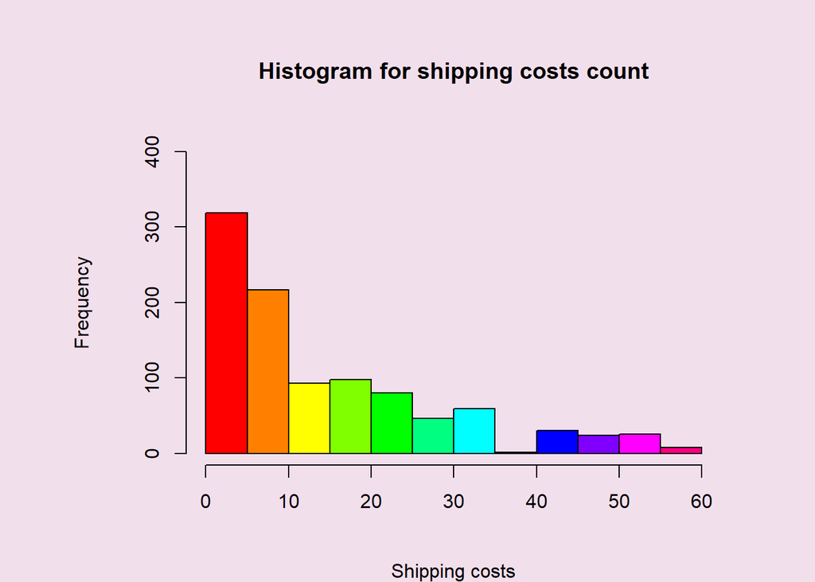

```r
par(bg = "#f2dfec")
hist(FinalData$Shipping_Cost_Each, ylim = c(0,400), xlim = c(0,60), xlab = "Shipping costs", ylab="Frequency", col = rainbow(12), main="Histogram for shipping costs count")
```

```r
Market=FinalData$Market
matrix_finaldata= matrix(table(Market),dimnames = list(c("Africa","Asia Pacific","Europe","LATAM", "USCA"), c("Frequency")))
library(knitr)
matrix_finaldata %>%
  kbl() %>%
  kable_material_dark("hover")
```

|  | Frequency |
| --- | --- |
| Africa | 62 |
| Asia Pacific | 302 |
| Europe | 261 |
| LATAM | 205 |
| USCA | 170 |

**Observations : **The above is an extra frequency table represents the list of different markets and their frequencies in the data. This is achieved using a matrix function.This shows the Asia Pacific has the highest frequency among all in the data and Africa has the least.****

[figure not shown]

```r
Table_fpro=knitr::kable(matrix_finaldata)
marketclass1=table(Market)
par(bg = "#5A8A67")
finalbplot=barplot(table(Market), col=rainbow(5),horiz = T, main="Returns per Market : Daliboyina Sasank Yadav",
   xlab="Frequency", ylab="Market",xlim = c(0,400),legend.text = rownames(marketclass1))
text(x=table(Market),finalbplot, table(Market), cex = 1,las=1, pos = 4)
```

**Observations : **The above extra barplot represents the same frequency table which is achieved before .For the better visualization the rainbow() function is used in barplot().Asia Pacific has the highest among all and africa with lowest frequency.****

**TASK 2:**

**Title : Shipping Cost each Variable.**

**Description : Distribution of Shipping cost each variable using boxplot and histogram.**

```r
par(mfcol=c(2,1),mai=c(3,3,0.2,0.4),mar=c(0,2,6,4))
meansce=round(mean(FinalData$Shipping_Cost_Each),2)
mediansce=round(median(FinalData$Shipping_Cost_Each),2)
par(bg = "#B8F1E8")
finalbxplot3=boxplot(FinalData$Shipping_Cost_Each, horizontal=TRUE, main="Box-Plot for Shipping Cost Each : Sasank Yadav Daliboyina",ylim=c(0,80),col = "blue")
finalbxplot3
```

```
## $stats
##        [,1]
## [1,]  0.000
## [2,]  3.890
## [3,]  8.585
## [4,] 21.415
## [5,] 47.700
##
## $n
## [1] 1000
##
## $conf
##          [,1]
## [1,] 7.709381
## [2,] 9.460619
##
## $out
##  [1] 50.84 52.50 53.96 49.18 49.43 49.15 49.48 51.37 50.63 53.25 52.73 55.10
## [13] 53.99 56.68 58.44 56.97 57.28 59.71 48.56 48.94 52.64 53.57 47.71 50.87
## [25] 50.98 51.23 51.74 52.16 52.83 53.93 55.57 55.95 48.69 49.52 49.63 49.77
## [37] 49.97 50.56 50.83 52.52 53.22 54.02 54.40 54.64 54.95
##
## $group
##  [1] 1 1 1 1 1 1 1 1 1 1 1 1 1 1 1 1 1 1 1 1 1 1 1 1 1 1 1 1 1 1 1 1 1 1 1 1 1 1
## [39] 1 1 1 1 1 1 1
##
## $names
## [1] ""
```

```r
abline(v=meansce,col="brown",lwd=2,lty=3)
abline(v=mediansce,col="green",lwd=2,lty=3)
finalhist1=hist(FinalData$Shipping_Cost_Each, main="Histogram for Shipping Cost Each : Sasank Yadav Daliboyina", xlab="Shipping Cost Each", ylab="Frequency",col=rainbow(6),horiz=T)
finalhist1
```

```
## $breaks
##  [1]  0  5 10 15 20 25 30 35 40 45 50 55 60
##
## $counts
##  [1] 319 217  93  98  80  46  59   1  30  24  25   8
##
## $density
##  [1] 0.0638 0.0434 0.0186 0.0196 0.0160 0.0092 0.0118 0.0002 0.0060 0.0048
## [11] 0.0050 0.0016
##
## $mids
##  [1]  2.5  7.5 12.5 17.5 22.5 27.5 32.5 37.5 42.5 47.5 52.5 57.5
##
## $xname
## [1] "FinalData$Shipping_Cost_Each"
##
## $equidist
## [1] TRUE
##
## attr(,"class")
## [1] "histogram"
```

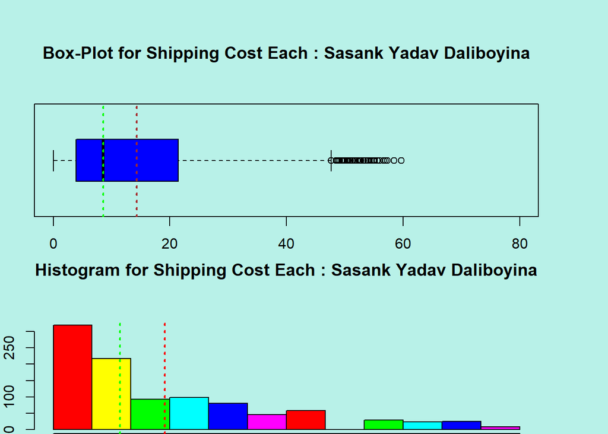

```r
abline(v=meansce,col="red",lwd=2,lty=3)
abline(v=mediansce,col="green",lwd=2,lty=3)
```

**Observations : **The above figures represents boxplots and histogram.The task requires to calculate mean() and median() of the shipping_cost_each variable and present the curve on both boxplots and histogram using abline() function. Hence, the mean is 14.32 and median is 8.58.****

**TASK 3:**

**Title : Shipping Costs Versus Market.**

**Description : Boxplot for market versus Shipping costs and pointing minimum and maximum shipping costs.**

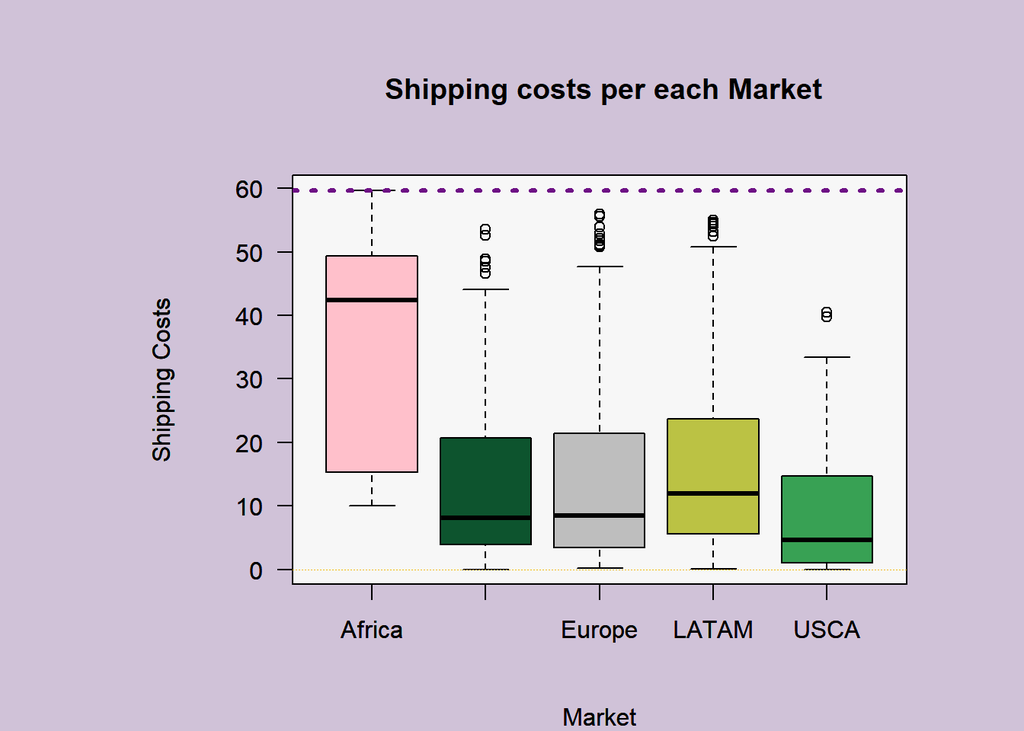

```r
par(bg = "#D0C2D8",mai=c(3,9,0,0),mar=c(5,10,6,4), mgp=c(4,1,0))
boxplot(FinalData$Shipping_Cost_Each~FinalData$Market,xlab = "Market", ylab = "Shipping Costs",las=1, main=" Shipping costs per each Market")
rect(par("usr")[1], par("usr")[3],
     par("usr")[2], par("usr")[4],
     col = "#f7f7f7")
max_sce=max(FinalData$Shipping_Cost_Each)
min_sce=min(FinalData$Shipping_Cost_Each)
par(new = TRUE)
boxplot(FinalData$Shipping_Cost_Each~FinalData$Market,xlab = "Market", ylab = "Shipping Costs", col =  c("pink","#0d542e","grey","#BBC244","#38A154"), las=1)
abline(h=max_sce,col="#6E1285",lwd=3,lty=3)
abline(h=min_sce,col="#F2B906",lwd=0,lty=3)
```

**Observations : **The above boxplots represents the individual markets shipping costs. Boxplot is the good option here to represent the minimum,maximum and quartiles. The abline() represents the minimum and maximum values of the distribution. Africa has the highest median among all other markets.USCA has the lowest distribution of both mean and median among others.The major distribution of shipping costs values of Africa lies between 15-40 below the median. LATAM and USCA has the maximum distribution above the median.The median of Africa is likely near to Q3 so it can be declared as a negative skew.Whereas AsiaPacific,Europe,LATAM,USCA are closely to first quartile thus are positively skewed. From the output, Asia Pacific and Europe has more number of outliers that means there are chances of more unusual data.More the outliers , more the prediction rate would be.USCA has less unsued data.****

**TASK 4:**

**Title : Shipping Costs per Market.**

**Description :Providing mean for shipping costs per market.**

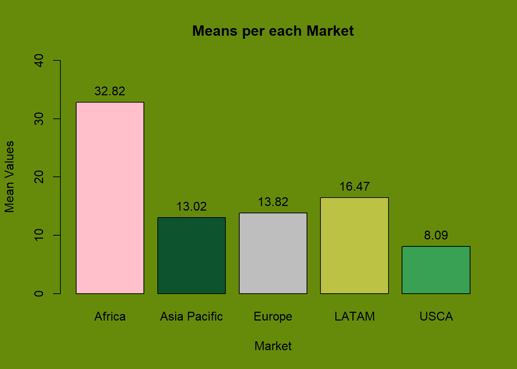

```r
Africa=dplyr::filter(FinalData, Market=="Africa")
AsiaPacific=dplyr::filter(FinalData, Market=="Asia Pacific")
Europe=dplyr::filter(FinalData, Market=="Europe")
LATAM=dplyr::filter(FinalData, Market=="LATAM")
USCA=dplyr::filter(FinalData, Market=="USCA")
mean_Africa=round(tapply(Africa$Shipping_Cost_Each,Africa$Market,mean),2)
mean_AsiaPacific=round(tapply(AsiaPacific$Shipping_Cost_Each,AsiaPacific$Market,mean),2)
mean_Europe=round(tapply(Europe$Shipping_Cost_Each,Europe$Market,mean),2)
mean_LATAM=round(tapply(LATAM$Shipping_Cost_Each,LATAM$Market,mean),2)
mean_USCA=round(tapply(USCA$Shipping_Cost_Each,USCA$Market,mean),2)
means_marketFinal= c(mean_Africa, mean_AsiaPacific, mean_Europe, mean_LATAM, mean_USCA)
par(bg = "#668B0B")
bxp_final=barplot(means_marketFinal, ylim = c(0,40), col = c("pink","#0d542e","grey","#BBC244","#38A154"), xlab = "Market", ylab = "Mean Values", main = "Means per each Market")
text(y = means_marketFinal, bxp_final,means_marketFinal,pos=3)
```

**Observations : **The above bar graph represents the mean values of each market. Used filter function to filter specific market. Using tapply() mean of each market’s shipping costs is calculated. As shown in the previous task, Africa has the highest median and distribution so as mean.LATAM market with next highest mean value. With the comparison we can infer skewness. As Asia Pacific is positively skewed the mean would be close to the first quartile.There is no much difference between the distribution of Asia Pacific and Europe.The more the close to the 1st quartile the less the median and mean is.Larger the range the more is the scattered data.****

**Description : (This is for extra 4 points) Median of Loss per Market for each market.**

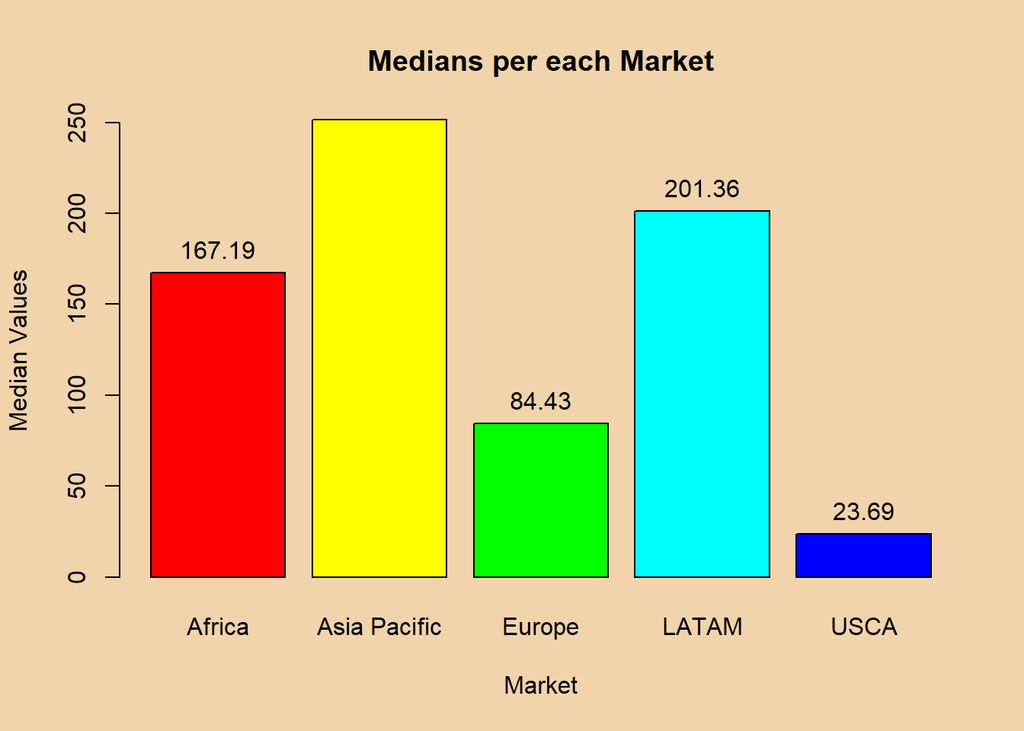

```r
Africa1=dplyr::filter(FinalData, Market=="Africa")
AsiaPacific1=dplyr::filter(FinalData, Market=="Asia Pacific")
Europe1=dplyr::filter(FinalData, Market=="Europe")
LATAM1=dplyr::filter(FinalData, Market=="LATAM")
USCA1=dplyr::filter(FinalData, Market=="USCA")
median_Africa1=round(tapply(Africa1$Loss_Per_Return,Africa1$Market,median),2)
median_AsiaPacific1=round(tapply(AsiaPacific1$Loss_Per_Return,AsiaPacific1$Market,median),2)
median_Europe1=round(tapply(Europe1$Loss_Per_Return,Europe1$Market,median),2)
median_LATAM1=round(tapply(LATAM1$Loss_Per_Return,LATAM1$Market,median),2)
median_USCA1=round(tapply(USCA1$Loss_Per_Return,USCA1$Market,median),2)
median_marketFinal1= c(median_Africa1,median_AsiaPacific1,median_Europe1,median_LATAM1,median_USCA1)
par(bg = "#F1D4AB")
bxp_final1=barplot(median_marketFinal1,col=rainbow(6),xlab="Market",ylab="Median Values",main="Medians per each Market")
text(y =median_marketFinal1, bxp_final1,median_marketFinal1,pos=3)
```

**Observations : The median is calculated for Loss_per_return variable. The variable is chosen based on the random sampling. The median value loss per return in Asia pacific is the highest and USCA being the lowest.**

[figure not shown]

```r
Africa2=dplyr::filter(FinalData, Market=="Africa")
AsiaPacific2=dplyr::filter(FinalData, Market=="Asia Pacific")
Europe2=dplyr::filter(FinalData, Market=="Europe")
LATAM2=dplyr::filter(FinalData, Market=="LATAM")
USCA2=dplyr::filter(FinalData, Market=="USCA")
sum_Africa2=round(tapply(Africa2$Returns,Africa2$Market,sum),2)
sum_AsiaPacific2=round(tapply(AsiaPacific2$Returns,AsiaPacific2$Market,sum),2)
sum_Europe2=round(tapply(Europe2$Returns,Europe2$Market,sum),2)
sum_LATAM2=round(tapply(LATAM2$Returns,LATAM2$Market,sum),2)
sum_USCA2=round(tapply(USCA1$Loss_Per_Return,USCA1$Market,sum),2)
sum_marketFinal2= c(sum_Africa2,sum_AsiaPacific2,sum_Europe2,sum_LATAM2,sum_USCA2)
par(bg = "#C8EE9B")
bxp_final2=barplot(sum_marketFinal2,col=rainbow(6),ylim=c(0,15000),xlab="Market",ylab="Sum of returns",main="Sum of Returns per each Market")
text(y =sum_marketFinal2, bxp_final2,sum_marketFinal2,pos=3)
```

**TASK 5:**

**Title : Shipping costs versus Shipping mode.**

**Description : Boxplot for Shipping Mode versus Shipping Costs**

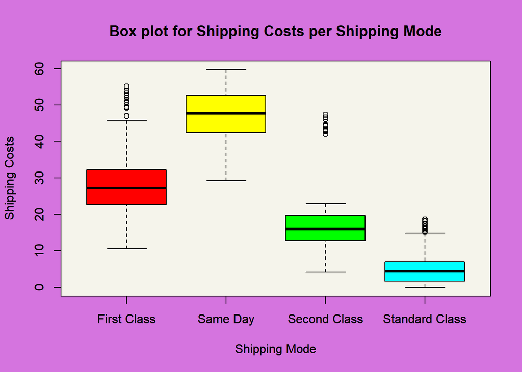

```r
par(bg = "#D574DF")
boxplot(FinalData$Shipping_Cost_Each~FinalData$ShipMode,xlab = "Shipping Mode", ylab = "Shipping Costs")
rect(par("usr")[1], par("usr")[3],
     par("usr")[2], par("usr")[4],
     col = "#f5f4eb")
par(new = TRUE)
boxplot(FinalData$Shipping_Cost_Each~FinalData$ShipMode,xlab = "Shipping Mode", ylab = "Shipping Costs",main="Box plot for Shipping Costs per Shipping Mode", col =  rainbow(6))
```

**TASK 6:**

**Title : A new glimpse.**

**Description : Providing glimpse() for new dataset adding new totalsales column**

```r
FinalData_new = FinalData %>%
  mutate(TotalSales = Product_Price*Quantity)
glimpse(FinalData_new[1,])
```

```
## Rows: 1
## Columns: 18
## $ OrderDate          <dttm> 2020-05-08
## $ ProductID          <chr> "TEC75553"
## $ City               <chr> "Yaounde"
## $ State              <chr> "Centre"
## $ Country            <chr> "Cameroon"
## $ Region             <chr> "Central Africa"
## $ Market             <chr> "Africa"
## $ Segment            <chr> "Home Office"
## $ Department         <chr> "Technology"
## $ Division           <chr> "Accessories"
## $ OrderPriority      <chr> "High"
## $ ShipMode           <chr> "First Class"
## $ Product_Price      <dbl> 360.04
## $ Quantity           <dbl> 154
## $ Shipping_Cost_Each <dbl> 50.84
## $ Returns            <dbl> 46
## $ Loss_Per_Return    <dbl> 126.01
## $ TotalSales         <dbl> 55446.16
```

**Observations : The glimpse function enables you to view each column in a data frame. It resembles str() when applied to a data frame, but it aims to display as much information as possible. At the end the new variable column named TotalSales is calculated and added.**

**TASK 7:**

**Title : Department Total sales.**

**Description : Using the same functionality of Task 6 calculating sum of total sales of each department.**

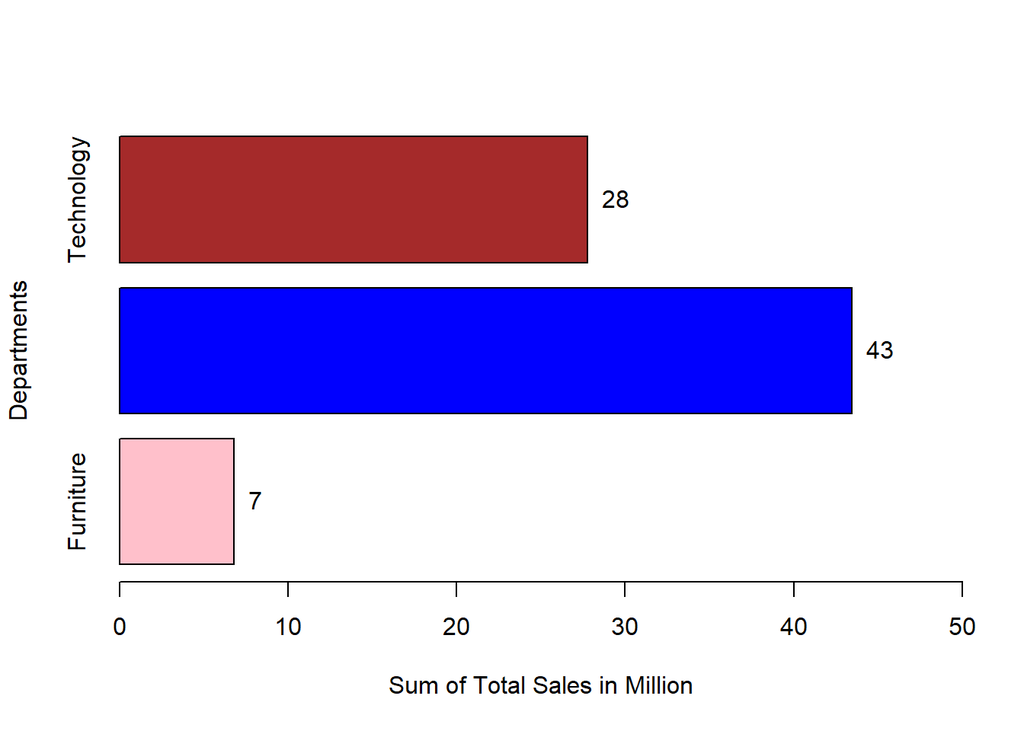

```r
df1=FinalData_new%>%
  group_by(Department)%>%
  summarise(DepartmentTotalSales=sum(TotalSales))


#for extra credit and good graphical representation, the sales is taken as million

df2=FinalData_new %>%
  group_by(Department) %>%
  dplyr::summarise(DepartmentTotalSales_in_Million = c(sum(TotalSales)/1000000))

df3=knitr::kable(df2,caption="Sales per Department")%>%
  kable_material_dark(html_font = "Calibiri", lightable_options = "striped")

Furniture=dplyr::filter(df2, Department=="Furniture")
OfficeSupplies=dplyr::filter(df2,Department=="Office Supplies")
Technology=dplyr::filter(df2, Department=="Technology")


OfficeSupplies_Sale1 =c(round(Technology$DepartmentTotalSales_in_Million,2),"M")




fbpl=barplot(round((df2$DepartmentTotalSales_in_Million),2)~unique(df2$Department),ylab = "Departments",xlab="Sum of Total Sales in Million",horiz=T,xlim=c(0,50),col=c("pink","blue","brown"))
text(x =df2$DepartmentTotalSales_in_Million, fbpl,round(df2$DepartmentTotalSales_in_Million),2,pos=4)
```

Sales per Department

| Department | DepartmentTotalSales_in_Million |
| --- | --- |
| Furniture | 6.77232 |
| Office Supplies | 43.46151 |
| Technology | 27.76457 |

**TASK 8:**

**Title : A Deep Critical Thinking.**

**Description : Using different functionalities answering the different set of codes.**

```r
accept=TRUE
reject=FALSE
fmedval = median(FinalData$Product_Price)

finaldata2 = FinalData%>%
  select(-c(OrderDate,ProductID,City,State,Country,Region,Department,Division,Quantity,ShipMode,Loss_Per_Return))

acceptfinaldata=finaldata2 %>%
  group_by(Segment) %>%
  filter(Product_Price < fmedval)%>%
   mutate(option = accept)

rejectfinaldata=finaldata2 %>%
  group_by(Segment) %>%
  filter(Product_Price > 2*fmedval)%>%
   mutate(option = reject)

option_finaltable=rbind(acceptfinaldata,rejectfinaldata)

option_finaltable%>%
  kbl()%>%
  kable_material_dark("hover",lightable_options = "striped",html_font = "Lucida Calligraphy")
```

| Market | Segment | OrderPriority | Product_Price | Shipping_Cost_Each | Returns | option |
| --- | --- | --- | --- | --- | --- | --- |
| Africa | Home Office | High | 360.04 | 50.84 | 46 | TRUE |
| Africa | Corporate | High | 407.63 | 52.50 | 31 | TRUE |
| Africa | Consumer | Medium | 415.82 | 53.96 | 52 | TRUE |
| Africa | Corporate | High | 288.35 | 45.87 | 29 | TRUE |
| Africa | Consumer | Critical | 334.33 | 47.00 | 102 | TRUE |
| Africa | Corporate | Critical | 255.87 | 49.18 | 71 | TRUE |
| Africa | Consumer | Critical | 322.30 | 49.43 | 96 | TRUE |
| Africa | Consumer | High | 293.27 | 49.15 | 10 | TRUE |
| Africa | Consumer | Medium | 461.66 | 49.48 | 27 | TRUE |
| Africa | Corporate | Critical | 321.02 | 51.37 | 88 | TRUE |
| Africa | Consumer | Medium | 415.71 | 50.63 | 32 | TRUE |
| Africa | Corporate | Critical | 300.16 | 52.73 | 10 | TRUE |
| Africa | Home Office | Medium | 387.05 | 55.10 | 51 | TRUE |
| Africa | Consumer | Critical | 264.01 | 53.99 | 15 | TRUE |
| Africa | Consumer | Critical | 274.78 | 56.68 | 9 | TRUE |
| Africa | Corporate | High | 324.05 | 58.44 | 38 | TRUE |
| Africa | Consumer | Medium | 340.68 | 56.97 | 83 | TRUE |
| Africa | Consumer | Critical | 401.42 | 57.28 | 6 | TRUE |
| Africa | Corporate | High | 312.19 | 59.71 | 112 | TRUE |
| Africa | Home Office | Critical | 301.97 | 44.21 | 37 | TRUE |
| Africa | Consumer | High | 371.46 | 43.04 | 109 | TRUE |
| Africa | Consumer | High | 402.05 | 42.75 | 47 | TRUE |
| Africa | Consumer | High | 349.40 | 44.63 | 87 | TRUE |
| Africa | Corporate | High | 358.29 | 44.32 | 64 | TRUE |
| Africa | Corporate | Medium | 448.83 | 44.59 | 43 | TRUE |
| Africa | Consumer | Critical | 288.74 | 46.63 | 33 | TRUE |
| Africa | Corporate | High | 421.00 | 46.20 | 15 | TRUE |
| Africa | Corporate | High | 407.00 | 11.09 | 64 | TRUE |
| Africa | Corporate | Low | 467.72 | 12.20 | 32 | TRUE |
| Africa | Consumer | High | 487.67 | 15.84 | 52 | TRUE |

[output cut: 529 more lines]

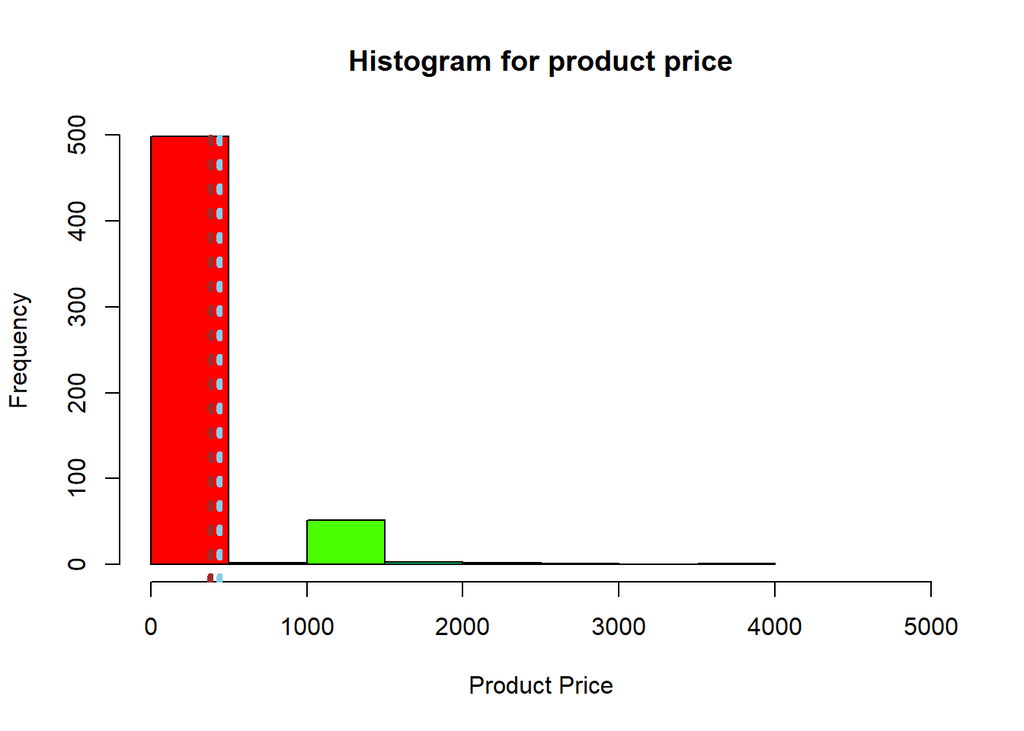

```r
hist(option_finaltable$Product_Price,main ="Histogram for product price", col = rainbow(7), xlim=c(0,5000),xlab="Product Price")
  abline(v = mean(option_finaltable$Product_Price),
  col = "skyblue",lwd=4,lty=3)
  abline(v = median(option_finaltable$Product_Price),
  col = "brown",lwd=4,lty=3)
```

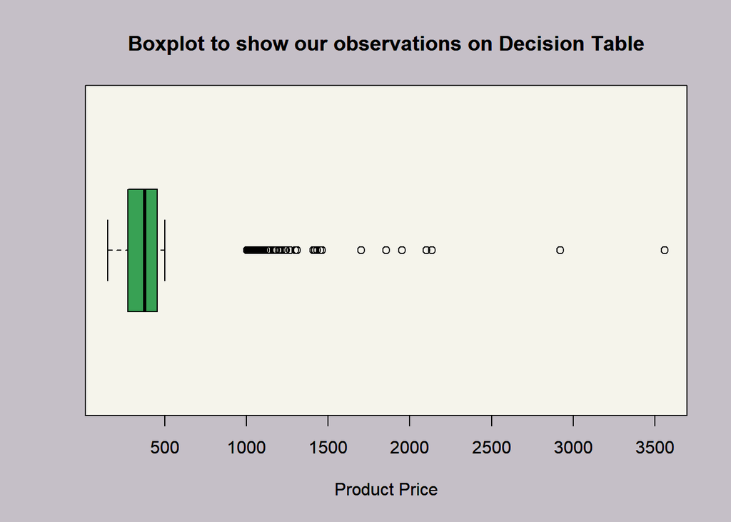

```r
  par(bg = "#c5bfc7")
boxplot(option_finaltable$Product_Price,horizontal = TRUE,main = "Boxplot to show our observations on Decision Table", xlab = "Product Price")
rect(par("usr")[1], par("usr")[3],
     par("usr")[2], par("usr")[4],
     col = "#f5f4eb")
par(new = TRUE)
boxplot(option_finaltable$Product_Price,horizontal = TRUE, xlab = "Product Price",main="Boxplot to show our observations on Decision Table", col =  "#38A154")
```

**BIBLIOGRAPHY :**

*1. &nbspProf Dee Chiluiza RPubs: Pie Charts , https://rpubs.com/Dee_Chiluiza/995745*

*2. Subset rows using column values https://dplyr.tidyverse.org/reference/filter.html*

*3. DataDaft YouTube video: dplyr: filter https://www.youtube.com/watch?v=BkmYBBM2SdQ.*

*4. Subset columns using their names and types https://dplyr.tidyverse.org/reference/select.html*

*5. Ed Boone YouTube video: Tidyverse in R… Select and Group By https://www.youtube.com/watch?v=timZ6erM7Z4*

*6. Bluman, A. G. (2003). A brief version elementary statistics a step by step approach (2nd ed.). Boston Burr Ridge: McGraw-Hill.*

*7. For kable_styling : https://www.rdocumentation.org/packages/kableExtra/versions/1.3.4/topics/kable_classic.*

*8. For binding of matrixes : https://www.geeksforgeeks.org/combining-matrices-in-r/*

*9. For INLINE R code : https://rmarkdown.rstudio.com/lesson-4.html*

*10. Smith, J. (2020). Introduction to R, RStudio, and R Markdown. Retrieved from https://bookdown.org/josiesmith/labbook/introduction-to-r-rstudio-and-r-markdown.html.*

*11. R Markdown: The Definitive Guide (2021). RStudio. https://bookdown.org/yihui/rmarkdown/*

**APPENDIX : An R Markdown(*.Rmd) file containing the R codes has been attached to this report. The name of this file is ALY6000FinalProject_Daliboyina.Rmd**

**THANKS CREDITS : During this course I have learnt many new business skills in the classroom from each and every person. Firstly, Thank you Professor DEE for this wonderful lectures I believe the skills which I have learned from this class will putforth in my upcoming organizations.The way of presenting project report from your perspective is very challenging at the beginning but later on due to some quite number of projects it got habituated. I strongly believe this presentation skills will be continued from my next classes.It is a great learning journey with you professor. Thank You.**

Best Regards,

Sasank Yadav Daliboyina